# Summary

This notebook contains my thoughts from Chapter 2 of Reinforcement Learning by Sutton and Barto, as well as some related readings. It is divided into the following sections:

**Experiments Overview:** I implemented many algorithms from the book and a few of my own, then compared them empirically using techniques from the book.

**Reading Response:** Questions and comments about the readings.

**Experiments:** The last (and largest) part of this notebook contains the implementations and results of my experiments.

# Experiments Overview

This section gives an overview of the experiments I performed while/after reading the chapter. All experiments are further down in this Jupyter notebook.

After reading the problem set-up in section 2.1 and before reading about any algorithms, I tried to come up with my own learning algorithm based on statistical t-tests. I implemented the algorithm and compared it to a baseline algorithm that always chooses randomly. I discuss several weaknesses of this approach and listed ideas for further exploration that I did not pursue.

Since section 2.8 on Gradient Ascent methods was specifically mentioned early in the lectures, before reading that section I came up with my own gradient method. It uses a loss function that I later learned is called "regret". I implemented and tested my gradient method.

I also implemented and compared the $\epsilon$-greedy, UCB, and Gradient Ascent methods.

Besides using a 10-armed bandit similar to the book, I also compared all methods using

1. a bandit whose reward distributions are highly skewed, and
2. a bandit whose reward distributions change over time. (This ended up being a precursor to the homework, but the homework itself is not included in this notebook.)

# Reading Response

Questions that I believe will be interesting for further discussion are highlighted in bold.

### Skewed reward distributions

The book only evaluates with normally distributed rewards. **How do the different techniques perform when the reward distribution is extremely skewed?**

To get a rough start on answering this question, I evaluated the $\epsilon$-greedy, UCB, and two gradient methods on a 10-armed bandit that gives rewards according to a log-normal distribution. I found that all methods performed poorly relative to a theoretically optimal strategy. The disparity in empirical performance is much larger when the reward distributions are skewed rather than symmetric.

This single experiment is just a start; it is not sufficient to make solid judgements about the techniques.

### UCB

I really like the UCB idea; I think it is a refinement of what I was trying to get at with the t-test method. I was curious where the exact equation came from, but I found the answer in the supplementary reading by Fischer et al (also referenced in the Bibliographic remarks for section 2.7 in the book).

### Real-world examples of bandit problems

The multi-armed slot machine example is illustrative, but it isn't interesting. **Are bandit problems studied because they are building-blocks for more interesting methods, or are they useful on their own? What are some examples of realistic applications of bandit methods?**

The readings are light on application examples. I found only two:

**Network routing:** The paper by Vermorel and Mohri suggests bandit algorithms can be used to solve the "CDN problem": Given multiple sources for some data, an agent has to decide how to minimize total latency by choosing which sources to connect to. I like this example very much; it is a realistic and clear example of a situation where a bandit method is useful on its own. There are many obvious variants of this exmple, such as a P2P client choosing between multiple peers.

**Clinical Trials:** The book and papers also give the example of choosing how to allocate patients in a clinitcal trial. I initially thought this example was contrived since there are many, many considerations that go into deciding when to execute a trial vs when to use known procedures. I doubt a clinical trial decision has ever been made based on a bandit algorithm, but I would be interested to be proven wrong.

It turns out that the cited paper is more nuanced and addresses the ethical concerns [[Hardwick and Stout 1991]](https://www.google.com/search?q=Bandit+Strategies+for+Ethical+Sequential+Allocation). Once participants are in a study, they can be allocated to treatment or control groups based on a bandit algorithm, with the reward being some measure of patient outcome. The goal of the algorithm is to maximize patient outcomes while still producing enough statistical power to make conclusions about the experimental treatment. Compared to allocating the participants equally between the two groups, the bandit algorithm will hopefully lead to more patients receiving the better treatment. I'm still not sure if there are other considerations in the messy world of clinical trials that would make bandit algorithms unusable, but it is definitely an interesting idea.

**A/B testing for software rollouts:** This is a new example. DevOps managers could use bandit algorithms to decide which version of code to deploy across a system in a manner similar to the clinical trial example.

# Experiments

This section contains all code and results of the experiments.

### Problem Set-up

To start, we use the simplest form of the problem: A 2-armed bandit with rewards normally distributed with unknown $\mu$ and $\sigma$.

```python
import numpy as np

class Bandit:
    def __init__(self, arms):
        self.rng = np.random.default_rng(0)
        self.arms = arms

    def reset(self, seed=0):
        '''
        Call reset() before each experiment to ensure the same sequence
        of arm pulls will produce the same rewards.
        '''
        self.rng = np.random.default_rng(seed)


class NormalBandit(Bandit):
    def __init__(self, mu, sigma):
        '''
        mu: A non-empty array-like of the expected values of rewards for each arm.
        sigma: A non-empty array-like of the standard-deviations of rewards for each arm.

        The lengths of mu and sigma much match.
        '''
        super().__init__(np.arange(len(mu)))

        if len(mu) != len(sigma):
            raise Exception("Length of `mu` and `sigma` must match.")

        if len(mu) == 0:
            raise Exception("`mu` and `sigma` must not be empty.")

        self.mu = np.array(mu, dtype=float)
        self.sigma = np.array(sigma, dtype=float)


    def pull(self, arm_index):
        '''
        Returns a reward after pulling the arm with the given index.
        '''
        return self.rng.normal( self.mu[arm_index], self.sigma[arm_index] )


bandit = NormalBandit( [0,1], [1,1] )
bandit.pull(0)
```

```
0.1257302210933933
```

We can use a violin plot to visualize the distribution of rewards:

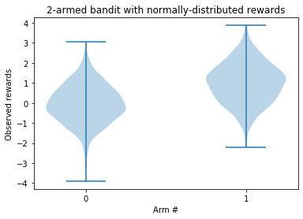

```python
# Build a violin plot to illustrate the distribution of rewards

import matplotlib.pyplot as plt

# Build dataset of 1000 pulls from each arm
num_pulls = 1000
data = [ [ bandit.pull(0) for _ in range(1, num_pulls) ],
         [ bandit.pull(1) for _ in range(1, num_pulls) ] ]

# Build plot
fig, ax = plt.subplots()
ax.set_title('2-armed bandit with normally-distributed rewards')
ax.set_ylabel('Observed rewards')

# Set axis labels
ax.xaxis.set_ticks_position('bottom')
ax.set_xticks([1, 2])
ax.set_xticklabels(['0', '1'])
ax.set_xlabel('Arm #')

ax.violinplot(data)
plt.show()
```

### Baseline: Random Strategy

We use an agent that pulls the arms randomly as a basline for comparison. We expect it's average reward to converge to 0.5 (the mean reward of the arms).

```python
class FixedExperiment:
    def __init__(self, bandit, total_timesteps):
        self.bandit = bandit
        self.total_timesteps = total_timesteps
        self.timestep = 0
        self.reward = np.empty(total_timesteps)
        self.optimal = np.empty(total_timesteps)

    def pull(self, arm):
        t = self.timestep

        # Update optimal
        # Must be done before pulling since bandits may change mu as part of pull()
        if arm == np.argmax(bandit.mu):
            self.optimal[t] = 1.0
        else:
            self.optimal[t] = 0.0

        # Pull arm and record reward
        r = self.bandit.pull(arm)
        self.reward[t] = r

        # Update timestep
        self.timestep += 1

        return r

colors = ["$\epsilon$-greedy", "t-test", "ucb", "ga_loss", "ga_book", "optimal", "ga1", "random"]

def plot_experiments(reward, optimal, names):
    fig, axs = plt.subplots(2)

    axs[0].set_ylabel("Average reward\nper timestep")
    axs[0].set_xlabel("Time step")
    for i, data in enumerate(reward):
        axs[0].plot(data, label=names[i], c=f"C{colors.index(names[i])}")

    axs[1].set_ylabel("Proportion of\noptimal choices\nper timestep")
    axs[1].set_xlabel("Time step")
    for i, data in enumerate(optimal):
        axs[1].plot(data, label=names[i], c=f"C{colors.index(names[i])}")

    handles, labels = axs[1].get_legend_handles_labels()
    fig.legend(handles, labels)

    return fig, axs


def run_random_experiment(__unused__=None, total_timesteps=1000):
    experiment = FixedExperiment(bandit, total_timesteps)

    for t in range(total_timesteps):
        experiment.pull(np.random.choice([0,1]))

    return experiment


def run_experiment(experiment_function, parameters={}, total_timesteps = 1000, trials = 1000):
    reward = np.zeros(total_timesteps)
    optimal = np.zeros(total_timesteps)

    for t in range(trials):
        bandit.reset(t)
        experiment = experiment_function(**parameters, total_timesteps=total_timesteps)
        reward += experiment.reward
        optimal += experiment.optimal

    return reward / trials, optimal / trials
```

```python
# Generate dataset
random_avg_reward, random_avg_optimal = run_experiment(run_random_experiment)
```

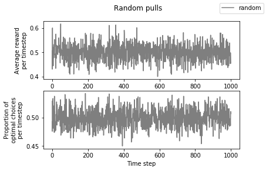

```python
# Plot the experiment
fig, _ = plot_experiments([random_avg_reward],
                          [random_avg_optimal],
                          ["random"])
fig.suptitle('Random pulls')
```

The random method chooses the best arm about half the time, as expected.

We can also plot a single run of the random method:

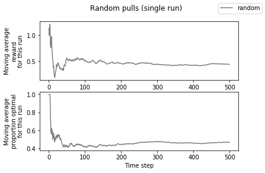

```python
# Plot a single run

def moving_average(a):
    '''
    Calculates a moving average over the array-like `a`.
    '''
    return np.cumsum(a, dtype=float) / (np.arange(len(a)) + 1)


# Generate dataset
reward, optimal = run_experiment(run_random_experiment, total_timesteps=500, trials = 1)

# Plot the experiment
fig, axs = plot_experiments([moving_average(reward)],
                            [moving_average(optimal)],
                            ["random"])
fig.suptitle('Random pulls (single run)')
axs[0].set_ylabel("Moving average\nreward\nfor this run")
axs[1].set_ylabel("Moving average\nproportion optimal\nfor this run")
```

We are likely to see significant oscillation in early timesteps, but eventually the average reward converges to 0.5.

### First Idea: Statistical t-test

My first idea was to alternate pulling each arm until we have a large enough sample size for a t-test to conclude that one arm is better than the other, at which point we switch to always pulling the better arm.

We need to use a Welch's t-test since we do not assume the distributions have equal variance.

```python
from scipy.stats import ttest_ind

def run_ttest_experiment(alpha = 0.05, total_timesteps = 1000):
    ttest_experiment = FixedExperiment(bandit, total_timesteps)

    # Naive implementation using off-the-shelf method. We could implement this as
    # a constant memory and time if we did the calculations ourselves.
    observations = [[], []]
    best_arm = -1

    for t in range(total_timesteps):

        if best_arm == -1:
            # We haven't found the best arm yet. Need a larger sample.
            arm = t % 2

            reward = ttest_experiment.pull(arm)

            observations[arm].append(reward)

            # Do t-tests when we have an equal number of observations for each arm
            if len(observations[0]) == len(observations[1]):

                _, p_value = ttest_ind(*observations, equal_var=False)

                if p_value < alpha:
                    # We can conclude one of the arms is better
                    best_arm = np.argmax([np.mean(o) for o in observations])

        else:
            reward = ttest_experiment.pull(best_arm)

    return ttest_experiment


ttest_avg_reward, ttest_avg_optimal = run_experiment(run_ttest_experiment)
```

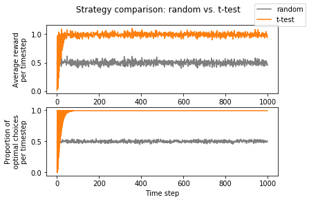

```python
# Plot the experiment
fig, _ = plot_experiments([random_avg_reward, ttest_avg_reward],
                          [random_avg_optimal, ttest_avg_optimal],
                          ["random", "t-test"])
fig.suptitle("Strategy comparison: random vs. t-test")
```

We will usually find the best lever and converge to the optimal average reward of 1.0, but there is nonzero chance that we will mistakenly think the wrong lever is the best one, and then pull the worst lever forever after!

Because of the way we set up this 2-sided t-test, I don't think the probability of choosing the wrong lever is as high as $\alpha$, and empirical evidence backs up this hunch. Using $\alpha=0.05$, only 6 out of 1000 runs of the t-test algorithm ultimately chose the wrong lever:

```python
# Proportion of runs that chose the best lever on the last 10 timesteps

ttest_avg_optimal[-10:]
```

```
array([0.994, 0.994, 0.994, 0.994, 0.994, 0.994, 0.994, 0.994, 0.994,
       0.994])
```

#### Discussion

As it is presented here, the t-test method only works for a 2-armed bandit. I see two ways to extend it to work with multi-armed bandits:

1. Run a tournament to eliminate poor-performing arms. The advantage of this method is it could be used to select the n-best bandit arms rather than just the single best by simply ending the tournament early. The n-best bandit arm problem was addressed in one of the supplementary readings.
2. We could use another statistical test. There are analogs to the t-test when considering multiple samples.

A more challenging problem would be to modify this approach to work with a non-stationary problem.

### Epsilon-greedy methods

Here I implement the $\epsilon$-greedy method as presented in the book.

```python
def run_epsilon_greedy_experiment(epsilon = 0.1, total_timesteps=1000):
    experiment = FixedExperiment(bandit, total_timesteps)

    values = np.zeros(len(bandit.arms))
    num_pulls = np.zeros(len(bandit.arms))
    for t in range(total_timesteps):
        if np.random.random() < epsilon:
            arm = np.random.choice(bandit.arms)
        else:
            arm = np.argmax(values)

        reward = experiment.pull(arm)

        num_pulls[arm] += 1
        # Equation 2.3:
        values[arm] = values[arm] + 1 / num_pulls[arm] * (reward - values[arm])

    return experiment


epsilon_greedy_avg_reward, epsilon_greedy_avg_optimal = run_experiment(run_epsilon_greedy_experiment)
```

[output not shown]

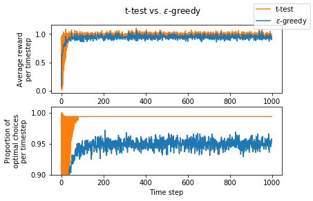

```python
# Plot the experiment
fig, axs = plot_experiments([ttest_avg_reward, epsilon_greedy_avg_reward],
                            [ttest_avg_optimal, epsilon_greedy_avg_optimal],
                            ["t-test", "$\epsilon$-greedy"])
fig.suptitle("t-test vs. $\epsilon$-greedy")
axs[1].set_ylim([0.90, 1.01])
```

In the long run, we expect the t-test algorithm to usually perform better than a simple $\epsilon$-greedy algorithm since the t-test will *usually* pick the optimal arm from some point on. As already mentioned, there is a small chance that the t-test algorithm will have terrible long-run performance. No other algorithm considered here has that flaw.

# Upper-Confidence-Bound

```python
from math import sqrt, log

def run_ucb_experiment(c = 1, total_timesteps=1000):
    experiment = FixedExperiment(bandit, total_timesteps)

    values = np.zeros(len(bandit.arms))
    num_pulls = np.zeros(len(bandit.arms))

    for t in range(total_timesteps):
        try:
            arm = num_pulls.tolist().index(0)
        except ValueError:
            # Equation 2.10
            arm = np.argmax([values[a] + c * sqrt(log(t+1) / num_pulls[a]) for a in bandit.arms])

        reward = experiment.pull(arm)

        num_pulls[arm] += 1

        # Equation 2.3:
        values[arm] = values[arm] + 1 / num_pulls[arm] * (reward - values[arm])

    return experiment


ucb_avg_reward, ucb_avg_optimal = run_experiment(run_ucb_experiment)
```

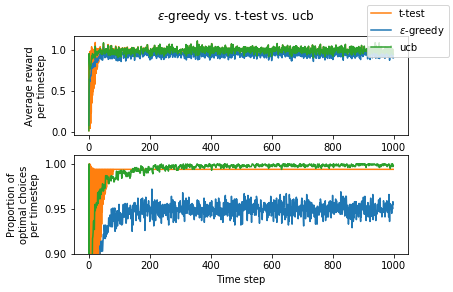

```python
# Plot the experiment
fig, axs = plot_experiments([ttest_avg_reward, epsilon_greedy_avg_reward, ucb_avg_reward],
                            [ttest_avg_optimal, epsilon_greedy_avg_optimal, ucb_avg_optimal],
                            ["t-test", "$\epsilon$-greedy", "ucb"])
axs[1].set_ylim([0.90, 1.01])
fig.suptitle("$\epsilon$-greedy vs. t-test vs. ucb")
```

UCB has several impportant advantages over the t-test method:

1. It is much easier to extent to a multi-armed bandit.
2. It does not depend on a normality assumption.

Furthermore, while the t-test method will have *usually* have optimal long-run performance when its assumptions are satisfied, the UCB method is *guaranteed* to have *very nearly* optimal long-run performance under the same assumptions. The UCB method does not have the grave drawback of occasionally converging to the wrong arm. I imagine the t-test method's chance of being very wrong is not worth the risk.

I really like the idea of UCB; it is my favorite method presented in the book. I reserve the right to change my oppinion as I learn more!

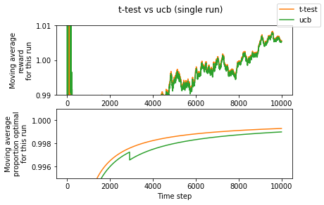

```python
# Plot a single run. Wrap in a function to prevent overwriting global variables

def __single_run():
    # Generate dataset
    ttest_reward, ttest_optimal = run_experiment(run_ttest_experiment, total_timesteps=10_000, trials = 1)
    ucb_reward, ucb_optimal = run_experiment(run_ucb_experiment, total_timesteps=10_000, trials = 1)

    # Plot the experiment
    fig, axs = plot_experiments([moving_average(ttest_reward), moving_average(ucb_reward)],
                                [moving_average(ttest_optimal), moving_average(ucb_optimal)],
                                ["t-test", "ucb"])
    fig.suptitle('t-test vs ucb (single run)')

    axs[0].set_ylabel("Moving average\nreward\nfor this run")
    axs[0].set_ylim(0.99, 1.01)
    axs[1].set_ylabel("Moving average\nproportion optimal\nfor this run")
    axs[1].set_ylim(0.995, 1.001)

__single_run()
```

Here we can compare a single run of the UCB and t-test methods. In this run, the t-test method found the best arm faster than the UCB method. We also see that the UCB occasionally checks the other arm.

### Gradient Methods

Before reading this section, I came up with two gradient methods of my own.

**Idea 1:** The probability of choosing an arm is defined as softmax of average sample rewards. As written, this isn't really a gradient algorithm. Rather, it's inspired by gradient descent algorithms I learned the previous day in my Deep Learning class.

**Idea 2:** Gradient descent on a loss function. We again define a set of probabilities for pulling each arm, then define the loss as the 2-norm of the vector difference between our current probability distribution and the "Dirac distribution" that always selects the arm with the highest sample average. I later learned that the loss function is sometimes called "regret".

This approach worked as well as the method presented in the book for the 2-armed bandit, the 10-armed bandit, and the 10-armed bandit with skewed reward distributions. It performed substantially worse on the non-stationary bandit. There is no reason to expect it to perform well on a non-stationary bandit since the loss function only makes sense if we assume the reward distribution means do not change over time. It may be possible to modify the loss function to work with non-stationary problems, but I don't see an easy way to do that right now.

#### Incorrect softmax algorithm

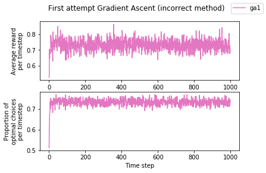

```python
def softmax(vals):
    '''
    `vals` must be a numpy array.
    '''
    total = np.sum(np.exp(vals))
    return np.exp(vals) / total


# This strategy doesn't actually work well, so I didn't take the time to make it work
# for anything other than a 2-armed bandit!
def run_ga1_experiment(total_timesteps=1000):
    experiment = FixedExperiment(bandit, total_timesteps)

    values = [0, 0]
    num_pulls = [0, 0]
    thetas = [0.5, 0.5]

    for t in range(total_timesteps):
        arm = np.random.choice([0,1], p=thetas)

        reward = experiment.pull(arm)

        num_pulls[arm] += 1

        # Equation 2.3:
        values[arm] = values[arm] + 1 / num_pulls[arm] * (reward - values[arm])

        thetas = softmax(values)

    return experiment


ga1_avg_reward, ga1_avg_optimal = run_experiment(run_ga1_experiment)

fig, ax = plot_experiments( [ ga1_avg_reward ],
                            [ ga1_avg_optimal ],
                            [ "ga1" ])
fig.suptitle("First attempt Gradient Ascent (incorrect method)")
```

#### Corrected softmax algorithm (from the book)

```python
def run_ga_book_experiment(step_size=0.5, total_timesteps=1000):
    experiment = FixedExperiment(bandit, total_timesteps)

    probabilities = np.ones(len(bandit.arms)) / len(bandit.arms)
    preferences = np.ones(len(bandit.arms))
    r_bar = 0

    for t in range(total_timesteps):
        arm = np.random.choice(bandit.arms, p=probabilities)

        reward = experiment.pull(arm)

        # Equation 2.12
        r_bar = t/(t+1)*r_bar + 1/(t+1)*reward
        for a in bandit.arms:
            if a == arm:
                preferences[a] = preferences[a] + step_size * (reward - r_bar) * (1.0 - probabilities[a])
            else:
                preferences[a] = preferences[a] - step_size * (reward - r_bar) * probabilities[a]

        probabilities = softmax(preferences)

    return experiment


ga_book_avg_reward, ga_book_avg_optimal = run_experiment(run_ga_book_experiment)
```

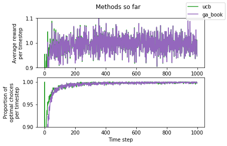

```python
# Plot the experiment
fig, axs = plot_experiments([ucb_avg_reward, ga_book_avg_reward],
                            [ucb_avg_optimal, ga_book_avg_optimal],
                            ["ucb", "ga_book"])
axs[0].set_ylim([0.90, 1.1])
axs[1].set_ylim([0.90, 1.01])
fig.suptitle("Methods so far")
```

#### Loss-descent algorithm

```python
def run_ga_loss_experiment(step_size=0.05, total_timesteps=1000):
    experiment = FixedExperiment(bandit, total_timesteps)

    values = np.zeros(len(bandit.arms))
    num_pulls = np.zeros(len(bandit.arms))
    thetas = np.ones(len(bandit.arms)) / len(bandit.arms)

    for t in range(total_timesteps):
        arm = np.random.choice(bandit.arms, p=thetas)

        reward = experiment.pull(arm)

        num_pulls[arm] += 1

        # Equation 2.3:
        values[arm] = values[arm] + 1 / num_pulls[arm] * (reward - values[arm])

        theta_star = np.zeros(len(bandit.arms))
        theta_star[np.argmax(values)] = 1.0

        # Take as step in the direction of the gradient
        thetas += step_size * 2 * (theta_star - thetas)
        # Clip and normalize Normalize
        thetas = np.clip(thetas, 0, 1)
        thetas /= thetas.sum()

    return experiment

ga_loss_avg_reward, ga_loss_avg_optimal = run_experiment(run_ga_loss_experiment)
```

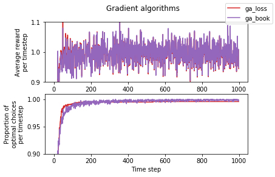

```python
# Plot the experiment
fig, axs = plot_experiments([ga_loss_avg_reward, ga_book_avg_reward],
                            [ga_loss_avg_optimal, ga_book_avg_optimal],
                            ["ga_loss", "ga_book"])
axs[0].set_ylim([0.90, 1.1])
axs[1].set_ylim([0.90, 1.01])
fig.suptitle("Gradient algorithms")
```

This simple gradient algorithm is a step in the right direction (pun intended), and performs almost as well as the method used in the book on this simple problem.

### Parameter Studies

The section reproduces the parameter study from Figure 2.6 in the book. We consider the 2-armed bandit here, then move to a 10-armed bandit below.

```python
def run_optimal_experiment(__unused__=0.0, total_timesteps=1000):
    experiment = FixedExperiment(bandit, total_timesteps)

    for t in range(total_timesteps):
        experiment.pull(np.argmax(bandit.mu))

    return experiment
```

```python
# Parameter Study

parameters = [1/128, 1/64, 1/32, 1/16, 1/8, 1/4, 1/2, 1, 2, 4]

def parameter_study(trials = 100, total_timesteps = 1000, exclude_ttest=False, start_i=0):

    experiments = {
        "epsilon_greedy": np.empty(len(parameters)),
        "ucb": np.empty(len(parameters)),
        "ga_book": np.empty(len(parameters)),
        "ga_loss": np.empty(len(parameters)),
        "optimal": np.empty(len(parameters)),
    }

    if not exclude_ttest:
        experiments["ttest"] = np.empty(len(parameters))

    for p, param in enumerate(parameters):
        print("running p =", p)

        if not exclude_ttest:
            experiments["ttest"][p] = run_experiment(
                run_ttest_experiment, {"alpha": param},
                total_timesteps=total_timesteps, trials=trials)[0][start_i:].mean()

        experiments["epsilon_greedy"][p] = run_experiment(
            run_epsilon_greedy_experiment, {"epsilon": param},
            total_timesteps=total_timesteps, trials=trials)[0][start_i:].mean()

        experiments["ucb"][p] = run_experiment(
            run_ucb_experiment, {"c": param},
            total_timesteps=total_timesteps, trials=trials)[0][start_i:].mean()

        experiments["ga_book"][p] = run_experiment(
            run_ga_book_experiment, {"step_size": param},
            total_timesteps=total_timesteps, trials=trials)[0][start_i:].mean()

        experiments["ga_loss"][p] = run_experiment(
            run_ga_loss_experiment, {"step_size": param},
            total_timesteps=total_timesteps, trials=trials)[0][start_i:].mean()

        experiments["optimal"][p] = run_experiment(
            run_optimal_experiment, {},
            total_timesteps=total_timesteps, trials=trials)[0][start_i:].mean()

    return experiments
```

```python
pstudy2 = parameter_study()
```

```
running p = 0
```

```
running p = 1
running p = 2
running p = 3
running p = 4
running p = 5
running p = 6
running p = 7
running p = 8
running p = 9
```

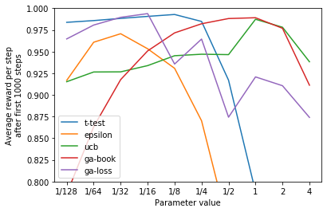

```python
plt.plot(pstudy2["ttest"])
plt.plot(pstudy2["epsilon_greedy"])
plt.plot(pstudy2["ucb"])
plt.plot(pstudy2["ga_book"])
plt.plot(pstudy2["ga_loss"])

plt.xlabel("Parameter value")
plt.xticks([0,1,2,3,4,5,6,7,8,9], ["1/128", "1/64", "1/32", "1/16", "1/8", "1/4", "1/2", "1", "2", "4"])

plt.ylim([0.80, 1.0])
plt.ylabel("Average reward per step\nafter first 1000 steps")

plt.legend(["t-test", "epsilon", "ucb", "ga-book", "ga-loss"])
```

This plot doesn't isn't as polished as the one from the book, but some of the same patterns stand-out.

I am pleased to see that the loss-descent algorithm may be a reasonable alternative to the gradient ascent algorithm from the book.

The t-test method also performs admirably well for this particular scenario, but sadly this this is the last we'll see of it. Extending it beyond a 2-armed bandit with normally distributed rewards will take a lot of work and doesn't seem worth it.

# 10-armed Bandit

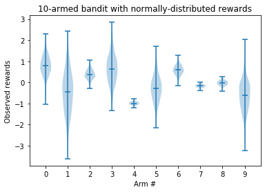

```python
# Build a violin plot to illustrate the distribution of rewards for our new 10-armed bandit

bandit = NormalBandit(np.random.uniform(-1,1, size=10), np.random.uniform(0,1, size=10))

# Build dataset of 1000 pulls from each arm
num_pulls = 1000
data = [ [ bandit.pull(a) for _ in range(1, num_pulls) ] for a in bandit.arms ]

# Build plot
fig, ax = plt.subplots()
ax.set_title('10-armed bandit with normally-distributed rewards')
ax.set_ylabel('Observed rewards')

# Set axis labels
ax.xaxis.set_ticks_position('bottom')
ax.set_xticks(np.arange(1,11))
ax.set_xticklabels(np.arange(0,10))
ax.set_xlabel('Arm #')

ax.violinplot(data, showmeans=True)
plt.show()
```

```python
# Same parameter study except no t-test
pstudy10 = parameter_study(exclude_ttest=True)
```

```
running p = 0
running p = 1
running p = 2
running p = 3
running p = 4
running p = 5
running p = 6
running p = 7
running p = 8
running p = 9
```

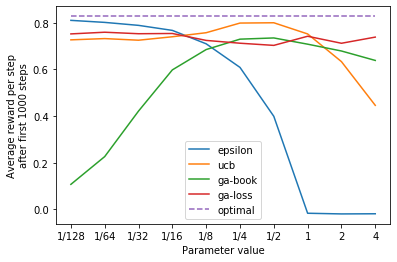

```python
plt.plot(pstudy10["epsilon_greedy"])
plt.plot(pstudy10["ucb"])
plt.plot(pstudy10["ga_book"])
plt.plot(pstudy10["ga_loss"])
plt.plot(np.repeat(np.max(bandit.mu), len(parameters)), linestyle="--")

plt.xlabel("Parameter value")
plt.xticks([0,1,2,3,4,5,6,7,8,9], ["1/128", "1/64", "1/32", "1/16", "1/8", "1/4", "1/2", "1", "2", "4"])

# plt.ylim([0.80, 1.0])
plt.ylabel("Average reward per step\nafter first 1000 steps")

plt.legend(["epsilon", "ucb", "ga-book", "ga-loss", "optimal"])
```

We start to see even more patterns matching the book's parameter study now that we use a 10-armed bandit. In particular, the UCB strategy performs the best, and is robust in a very large range of parameter values.

The loss-descent algorithm is still competitive with the gradient-ascent algorithm from the book. Interestingly, it does not seem to be particularly sensitive to step size.

# Highly skewed rewards

```python
class LognormalBandit(Bandit):

    def __init__(self, mu, sigma):
        '''
        mu: A non-empty array-like of the expected values of rewards for each arm.
        sigma: A non-empty array-like of the standard-deviations of rewards for each arm.

        The lengths of mu and sigma much match.
        '''
        super().__init__(np.arange(len(mu)))

        if len(mu) != len(sigma):
            raise Exception("Length of `mu` and `sigma` must match.")

        if len(mu) == 0:
            raise Exception("`mu` and `sigma` must not be empty.")

        self.mu = np.array(mu, dtype=float)
        self.sigma = np.array(sigma, dtype=float)


    def pull(self, arm_index):
        '''
        Returns a reward after pulling the arm with the given index.
        '''
        return self.rng.lognormal( self.mu[arm_index], self.sigma[arm_index] )
```

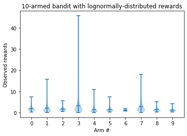

```python
# Build a violin plot to illustrate the distribution of rewards for our new 10-armed bandit

bandit = LognormalBandit(np.random.uniform(0,1, size=10), np.random.uniform(0.1,1, size=10))

# Build dataset of 1000 pulls from each arm
num_pulls = 1000
data = [ [ bandit.pull(a) for _ in range(1, num_pulls) ] for a in bandit.arms ]

# Build plot
fig, ax = plt.subplots()
ax.set_title('10-armed bandit with lognormally-distributed rewards')
ax.set_ylabel('Observed rewards')

# Set axis labels
ax.xaxis.set_ticks_position('bottom')
ax.set_xticks(np.arange(1,11))
ax.set_xticklabels(np.arange(0,10))
ax.set_xlabel('Arm #')

ax.violinplot(data, showmeans=True)
plt.show()
```

Numpy's random.lognormal distribution accepts the mean of the underlying normal distribution, so the mean of the log-normal distribution is $\exp(\mu + \frac{\sigma^2}{2})$:

Theoretical means:

```python
log_normal_mu = np.exp(bandit.mu + bandit.sigma**2/2)
log_normal_mu
```

```
array([1.9912204 , 2.05848507, 1.7548388 , 3.19948617, 1.45327489,
       1.52546233, 1.25923096, 2.79121454, 1.40885897, 1.17039154])
```

Observed means:

```python
np.array(data).mean(1)
```

```
array([1.93669515, 2.05838767, 1.7191493 , 3.37917111, 1.47775332,
       1.53645426, 1.26155609, 2.8114648 , 1.43164199, 1.17116297])
```

```python
# Same parameter study again
pstudy_skewed = parameter_study(exclude_ttest=True)
```

```
running p = 0
running p = 1
running p = 2
running p = 3
running p = 4
running p = 5
running p = 6
running p = 7
running p = 8
running p = 9
```

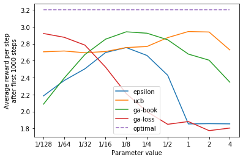

```python
plt.plot(pstudy_skewed["epsilon_greedy"])
plt.plot(pstudy_skewed["ucb"])
plt.plot(pstudy_skewed["ga_book"])
plt.plot(pstudy_skewed["ga_loss"])
plt.plot(np.repeat(np.max(log_normal_mu), len(parameters)), linestyle="--")

plt.xlabel("Parameter value")
plt.xticks([0,1,2,3,4,5,6,7,8,9], ["1/128", "1/64", "1/32", "1/16", "1/8", "1/4", "1/2", "1", "2", "4"])

plt.ylabel("Average reward per step\nafter first 1000 steps")

plt.legend(["epsilon", "ucb", "ga-book", "ga-loss", "optimal"])
```

Compared to normally-distributed rewards, there is not much difference between the performance of the methods relative to one another. The UCB method still performs the best and has a large range of useful parameter values. The gradient methods perform similarly for their respective best parameters, and $\epsilon$-greedy is still competitive but doesn't perform quite as well.

One interesting difference is none of the methods perform nearly as well with respect to a theoretically optimal strategy. In the normal case, many methods could find the best arm within 1000 timesteps, while all the methods struggle when the reward distributions are highly skewed. This suggests that there may be room for improvement for highly-skewed reward distributions.

### Non-stationary rewards

This section explores performance when the reward distributions change over time.

*The question posed in the homework is not included here.* I did not explore the affect of using a constant step-size when updating sample averages.

```python
# Uses parameters from exercise 5
class NonstationaryNormalBandit(Bandit):

    def __init__(self):
        super().__init__(np.arange(10))
        self.mu = np.zeros(10, dtype=float)

    def pull(self, arm_index):
        '''
        Returns a reward after pulling the arm with the given index.
        '''
        reward = self.rng.normal( self.mu[arm_index], 1.0 )

        self.mu += self.rng.normal( 0.0, 0.01, 10 )

        return reward

    def reset(self, seed):
        # We also need to reset the mu's
        super().reset(seed)
        self.mu = np.zeros(10, dtype=float)


bandit = NonstationaryNormalBandit()
```

```python
pstudy_nonstationary = parameter_study(exclude_ttest=True, total_timesteps=10_000, start_i=-1000)
```

```
running p = 0
running p = 1
running p = 2
running p = 3
running p = 4
running p = 5
running p = 6
running p = 7
running p = 8
running p = 9
```

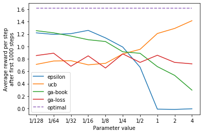

```python
plt.plot(pstudy_nonstationary["epsilon_greedy"])
plt.plot(pstudy_nonstationary["ucb"])
plt.plot(pstudy_nonstationary["ga_book"])
plt.plot(pstudy_nonstationary["ga_loss"])
plt.plot(pstudy_nonstationary["optimal"], linestyle="--")

plt.xlabel("Parameter value")
plt.xticks([0,1,2,3,4,5,6,7,8,9], ["1/128", "1/64", "1/32", "1/16", "1/8", "1/4", "1/2", "1", "2", "4"])

plt.ylabel("Average reward per step\nafter first 1000 steps")

plt.legend(["epsilon", "ucb", "ga-book", "ga-loss", "optimal"])
```

Interestingly, the simple $\epsilon$-greedy method now performs very well compared to the other methods!

As already mentioned, there is no reason to expect my loss-descent algorithm to perform well in this scenario. Indeed, it performs substantially worse than all other methods.

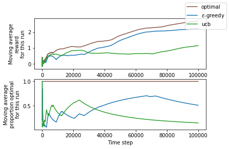

```python
# Single run

# Generate dataset
optimal_reward, optimal_optimal = run_experiment(
    run_optimal_experiment, {}, total_timesteps=100_000, trials = 1)

epsilon_reward, epsilon_optimal = run_experiment(
    run_epsilon_greedy_experiment, {"epsilon": 1/64}, total_timesteps=100_000, trials = 1)

ucb_reward, ucb_optimal = run_experiment(
    run_ucb_experiment, {"c": 2}, total_timesteps=100_000, trials = 1)

# Plot the experiment
fig, axs = plot_experiments( [ moving_average(optimal_reward),
                               moving_average(epsilon_reward),
                               moving_average(ucb_reward) ],
                             [ moving_average(optimal_optimal),
                               moving_average(epsilon_optimal),
                               moving_average(ucb_optimal) ],
                            ["optimal", "$\epsilon$-greedy", "ucb"])
fig.suptitle('')
axs[0].set_ylabel("Moving average\nreward\nfor this run")
axs[1].set_ylabel("Moving average\nproportion optimal\nfor this run")
```

When we look at a single run, we can see when the UCB and $\epsilon$-greedy methods are able to find the best arm, and how long it takes them to realize there is a new best arm. As time goes on, it takes longer and longer for the methods to switch to the new best arm. This problem may be partially addressed by using constant step-size when computing sample averages